# Recitation week 14: Categorical Data Ideas

To Do:

- side-by-side and stacked bar plots in ggplot? (See deer example and soccer example from lecture. Makes sense for context 1 contingency analysis). Add at end.
- Odds ratio (I think reported by `g.test()` or `chisq.test()` maybe?)

# Goodness of fit

## Chi-square

Using already tabulated data. By default, the `chisq.test()` function wants observed values and expected probabilities.

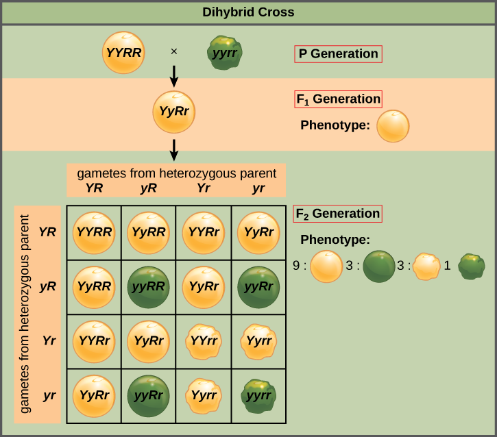

```r
include_graphics("https://upload.wikimedia.org/wikipedia/commons/0/03/Figure_12_03_02.png")
```

```r
#Actual
Obs <- c(yellowround = 93, yelowwrinkled = 28, greenround = 31, greenwrinkled = 8)
#Expected probabilities
Exp.p <- c(9/16, 3/16, 3/16, 1/16)
chisq.test(Obs, p = Exp.p)
```

```
    Chi-squared test for given probabilities

data:  Obs
X-squared = 0.66667, df = 3, p-value = 0.881
```

**NOTE:** You *must* used a named argument for `p =`! `chisq.test(Obs, p)` will give you **different results**.

But you can also give it expected values or expected proportions if you include `rescale.p = TRUE`

```r
#Expected values
Exp <- c(yellowround = 90, yelowwrinkled = 30, greenround = 30, greenwrinkled = 10)
sum(Obs) == sum(Exp)
```

```
[1] TRUE
```

```r
chisq.test(Obs, p = Exp, rescale.p = TRUE)
```

```
    Chi-squared test for given probabilities

data:  Obs
X-squared = 0.66667, df = 3, p-value = 0.881
```

```r
#Expected ratio
props <- c(9, 3, 3, 1)
chisq.test(Obs, p = props, rescale.p = TRUE)
```

```
    Chi-squared test for given probabilities

data:  Obs
X-squared = 0.66667, df = 3, p-value = 0.881
```

## Exact binomial test

If there are only two categories, you can use a binomial test. Here’s an example from the help file of `binom.test()`:

> Under (the assumption of) simple Mendelian inheritance, a cross between plants of two particular genotypes produces progeny 1/4 of which are “dwarf” and 3/4 of which are “giant”, respectively. In an experiment to determine if this assumption is reasonable, a cross results in progeny having 243 dwarf and 682 giant plants. If “giant” is taken as success, the null hypothesis is that $p = 3/4$ and the alternative that $p ≠ 3/4$.

Conover (1971), p. 97f.

```r
binom.test(c(682, 243), p = 3/4)
```

```
    Exact binomial test

data:  c(682, 243)
number of successes = 682, number of trials = 925, p-value = 0.3825
alternative hypothesis: true probability of success is not equal to 0.75
95 percent confidence interval:
 0.7076683 0.7654066
sample estimates:
probability of success
             0.7372973
```

Data are in agreement with the null hypothesis

## G-test

There is no G-test for goodness-of-fit available in R, and it’s so easy to calculate by hand! R is a really good calculator to use because it is *vectorized*. That is, when you multiply a vector by a number, the operation applies to all elements of a vector. This will make it easy to calculate everything inside the summation.
$$G = 2\bigg[\sum_i{O\ln\bigg(\frac{O}{E} \bigg)} \bigg]$$
### Define observed and expected

```r
#data from dihybrid cross
Obs #observed numbers
```

```
  yellowround yelowwrinkled    greenround greenwrinkled
           93            28            31             8
```

```r
Exp.p #expected probabilities
```

```
[1] 0.5625 0.1875 0.1875 0.0625
```

```r
#calculate expected numbers from probabilities
Obs.sum = sum(Obs)
Exp = Obs.sum * Exp.p
Exp
```

```
[1] 90 30 30 10
```

### Calculate G

```r
OEratio = Obs/Exp #creates a vector from two vectors by dividing the first element of Obs by the first element of Exp, the second by the second, etc.
OEratio
```

```
  yellowround yelowwrinkled    greenround greenwrinkled
    1.0333333     0.9333333     1.0333333     0.8000000
```

```r
G = sum(log(OEratio)*Obs) * 2
G
```

```
[1] 0.6979784
```

### Find p-value

Look up the p-value from the chi squared distribution using `pchisq()`

```r
p = pchisq(G, length(Obs) - 2, lower.tail = FALSE)
p
```

```
[1] 0.7054007
```

### Making a g-test function

First, put all the code together

```r
Obs.sum = sum(Obs)
Exp = Obs.sum * Exp.p
G = sum(log(Obs/Exp)*Obs) * 2
G
```

```
[1] 0.6979784
```

```r
p = 1 - pchisq(G, length(Obs) - 2)
p
```

```
[1] 0.7054007
```

Then select it and choose “Extract Function” from the “Code” menu. When prompted, call it “mygtest”.

```r
#after extracting it as a function
mygtest <- function(Obs, Exp.p) {
  Obs.sum = sum(Obs)
  Exp = Obs.sum * Exp.p
  G = sum(log(Obs/Exp)*Obs) * 2
  G
  p = 1 - pchisq(G, length(Obs) - 2)
  p
}
```

Now you should see a new function called “mygtest” in the Environment tab to the right. You can now use your function on new data.

```r
mygtest(Obs = c(85, 25, 30, 20), Exp.p = c(9/16, 3/16, 3/16, 1/16))
```

```
[1] 0.01172022
```

Notice that it only displays the last thing printed out in the code of the function. We can make it show both the G test statistic and the p-value by using `return()`

```r
mygtest <- function(Obs, Exp.p) {
  Obs.sum = sum(Obs)
  Exp = Obs.sum * Exp.p
  G = sum(log(Obs/Exp)*Obs) * 2
  G
  p = 1 - pchisq(G, length(Obs) - 2)
  p
  return(list(G = G, p = p))
}
mygtest(Obs = c(85, 25, 30, 20), Exp.p = c(9/16, 3/16, 3/16, 1/16))
```

```
$G
[1] 8.892879

$p
[1] 0.01172022
```

Save this and feel free to use it on your take-home!

# Contingency Analysis

Context 1: Fixed number of individuals assigned to or included in 2 or more groups (categorical explanatory variable). Measure categorical response variable. Column or row totals are predetermined. Stacked bar plots might make more sense for this.

Context 2: Random sample with 2 categorical variables measured on each subject. Only n is fixed, any observation can have any combination of the two categorical variables.

## Contingency Tables

The first step in contingency analysis in R is to convert a tidy data frame, in which each row is an observation and each column is a variable (in this case, both columns are a factor), into a contingency table where rows represent one factor and columns represent another. This can be done with the `table()` function.

### Starting with frequency data (Context 1)

If you already have frequency data, you can use `xtabs()` with a formula interface to create a contingency table object.

Angina treatment data from lecture

```r
angina <- read.csv("Angina.csv")
angina
```

| Treatment | Symptoms | Freq |
| --- | --- | --- |
| Timelol | No_Angina | 44 |
| Timelol | Angina | 116 |
| Placebo | No_Angina | 19 |
| Placebo | Angina | 128 |

```r
angina.table <- xtabs(Freq ~ Treatment + Symptoms, data = angina)
# Freq ~ Treatment + Symptoms can be read as "frequency distributed as Treatment and Angina status"
angina.table
```

```
         Symptoms
Treatment Angina No_Angina
  Placebo    128        19
  Timelol    116        44
```

```r
addmargins(angina.table)
```

```
         Symptoms
Treatment Angina No_Angina Sum
  Placebo    128        19 147
  Timelol    116        44 160
  Sum        244        63 307
```

### Starting with “tidy” data (Context 2)

Example 9.4 from the text. Are fish infected by a trematode worm eaten or not?

```r
worm <- read.csv("WormGetsBird.csv")
worm
```

| fishID | infection | bird_predation |
| --- | --- | --- |
| 1 | uninfected | eaten |
| 2 | lightly | eaten |
| 3 | lightly | eaten |
| 4 | lightly | eaten |
| 5 | lightly | eaten |
| 6 | lightly | eaten |
| 7 | lightly | eaten |
| 8 | lightly | eaten |
| 9 | lightly | eaten |
| 10 | lightly | eaten |

[output cut: 131 more lines]

In this data set, each row is a fish and the columns tell you whether each fish was uninfected, lightly infected, or highly infected and whether it was eaten or not.

```r
worm.table <- table(worm$bird_predation, worm$infection) #first argument is the rows, second is the columns
worm.table #contingency table
```

```
            highly lightly uninfected
  eaten         37      10          1
  not eaten      9      35         49
```

```r
addmargins(worm.table) #add row and column sums to display
```

```
            highly lightly uninfected Sum
  eaten         37      10          1  48
  not eaten      9      35         49  93
  Sum           46      45         50 141
```

### Exercise 1: Starting with contingency tables

```r
library(tibble)
df <- tribble(~factor1, ~factor2, ~freq,
              "A",      "YES",    35,
              "A",      "NO",     22,
              "B",      "YES",    55,
              "B",      "NO",     100)
df
```

| factor1 | factor2 | freq |
| --- | --- | --- |
| A | YES | 35 |
| A | NO | 22 |
| B | YES | 55 |
| B | NO | 100 |

Answer:

```r
snails <- tribble(~predation, ~color,     ~freq,
                  "Broken",   "Banded",   182,
                  "Broken",   "Unbanded", 116,
                  "Intact",   "Banded",   403,
                  "Intact",   "Unbanded", 385)
snails
```

| predation | color | freq |
| --- | --- | --- |
| Broken | Banded | 182 |
| Broken | Unbanded | 116 |
| Intact | Banded | 403 |
| Intact | Unbanded | 385 |

```r
snails.table <- xtabs(freq ~ color + predation, data = snails)
addmargins(snails.table)
```

```
          predation
color      Broken Intact  Sum
  Banded      182    403  585
  Unbanded    116    385  501
  Sum         298    788 1086
```

```r
chisq.test(snails.table)
```

```
    Pearson's Chi-squared test with Yates' continuity correction

data:  snails.table
X-squared = 8.1877, df = 1, p-value = 0.004217
```

Or:

```r
snail.matrix <- matrix(c(182, 403, 116, 385), nrow = 2, ncol = 2, byrow = TRUE)
snail.table2 <- as.table(snail.matrix)
rownames(snail.table2) <- c("Banded", "Unbanded")
colnames(snail.table2) <- c("Broken", "Intact")
snail.table2
```

```
         Broken Intact
Banded      182    403
Unbanded    116    385
```

```r
addmargins(snail.table2)
```

```
         Broken Intact  Sum
Banded      182    403  585
Unbanded    116    385  501
Sum         298    788 1086
```

```r
chisq.test(snail.table2)
```

```
    Pearson's Chi-squared test with Yates' continuity correction

data:  snail.table2
X-squared = 8.1877, df = 1, p-value = 0.004217
```

## Releveling Factors

By default, when made into a factor, R uses alphabetical order. This order usually isn’t important but can affect the appearance of plots (e.g. mosaic plots and barplots) and some statistical analyses (e.g. Dunnett’s Test).

```r
snails$color <- as.factor(snails$color)
snails$color
```

```
[1] Banded   Unbanded Banded   Unbanded
Levels: Banded Unbanded
```

```r
levels(snails$color)
```

```
[1] "Banded"   "Unbanded"
```

```r
#first observation is "Banded", first level is "Banded"
#manually set levels
snails$color <- factor(snails$color, levels = c("Unbanded", "Banded"))
snails$color
```

```
[1] Banded   Unbanded Banded   Unbanded
Levels: Unbanded Banded
```

```r
#first observation is still "Banded" doesn't change data.  First level is "Unbanded"
#DON'T do this:
# levels(snails$color) <- c("Unbanded", "Banded")
#That just re-names the levels.  It will change the underlying data!!!
```

Watch out for typos! R will **not** give an error message when using this method.

```r
test <- factor(snails$color, levels = c("Ubanded", "Banded"))
test
```

```
[1] Banded <NA>   Banded <NA>
Levels: Ubanded Banded
```

If you’re doing a lot of work with categorical data, I highly recommend the package `forcats`. It has many fucntions for re-ordering levels different ways (by frequency, by some function of another column, in reverse order, etc.)

```r
library(forcats)
fct_reorder(snails$color, snails$freq) #re-order the color factor by the frequency column
```

```
[1] Banded   Unbanded Banded   Unbanded
Levels: Unbanded Banded
```

## Chi-square

Chi-square tests can also be used for contingency analysis. To conduct a chi-square test of independence first, you convert a data frame to a contingency table using `xtabs()`. Then use `summary()` on that table to get chi-squre results. You could also use `chisq.test()` on the table. By default, chisq.test uses the **Yates correction for continuity** (see ?chisq.tes() and page 251 of your textbook). Set `correct = FALSE` to get the same results as `summary()`.

```r
summary(worm.table)
```

```
Number of cases in table: 141
Number of factors: 2
Test for independence of all factors:
    Chisq = 69.76, df = 2, p-value = 7.124e-16
```

```r
chisq.test(worm.table, correct = FALSE)
```

```
    Pearson's Chi-squared test

data:  worm.table
X-squared = 69.756, df = 2, p-value = 7.124e-16
```

## G-test

There are no base R functions for G-tests, but functions for contingency table analysis with G-tests are found in a few packages including `DescTools` (`GTest()`) and `RVAideMemoire` (`G.test()`). However, rather than having you install a whole package just for one function we can use the function provided by Brent Larget, recommended by your textbook authors.

```r
source("http://www.stat.wisc.edu/~st571-1/gtest.R")
#source works kind of like library(), but for single .R files instead of packages.
```

After running the code above, you should see a new function in your Environment tab, `g.test()`. This function also works on contingency table objects.

```r
g.test(worm.table)
```

```
G-Test for Contingency Tables

Data:

            highly lightly uninfected
  eaten         37      10          1
  not eaten      9      35         49

The test statistic is  77.897 .
There are  2  degrees of freedom.
The p-value is  0 .
```

Reject null hypothesis. There is an association between worm infection and predation by birds.

## Fisher’s Exact Test

Fisher’s exact test (`fisher.test()`) is for 2x2 contingency tables with small n. It also works on contingency table objects.

Example 9.5 in your text. Do vampire bats prefer to feed on cows in estrous?

```r
vampire <- read.csv("VampireBites.csv")
vampire.table <- table(vampire$bitten, vampire$estrous)
vampire.table
```

```
             estrous no estrous
  bitten          15          6
  not bitten       7        322
```

```r
fisher.test(vampire.table)
```

```
    Fisher's Exact Test for Count Data

data:  vampire.table
p-value < 2.2e-16
alternative hypothesis: true odds ratio is not equal to 1
95 percent confidence interval:
  29.94742 457.26860
sample estimates:
odds ratio
  108.3894
```

Reject null hypothesis, vampire bats prefer cows in estrous

## Stacked bar plots

The base R function `barplot()` works on contingency table objects

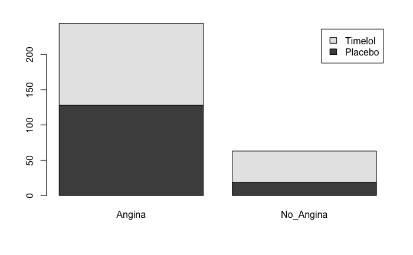

```r
barplot(angina.table, legend.text = TRUE)
```

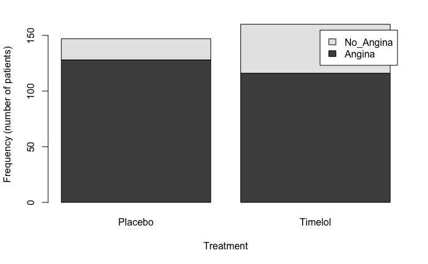

```r
# We probably want the treatment on the x-axis.  Transpose the data with t()
barplot(t(angina.table), legend.text = TRUE,
        xlab = "Treatment",
        ylab = "Frequency (number of patients)")
```

ggplot always needs a data frame, so we have to start with the frequency table

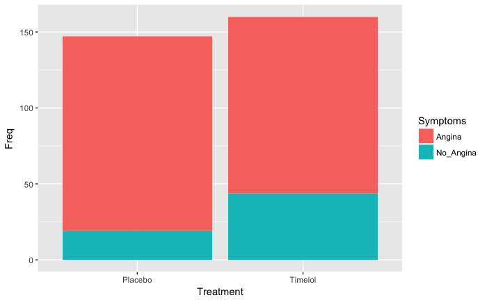

```r
#plotted as frequency
ggplot(angina) +
  geom_col(aes(x = Treatment, y = Freq, fill = Symptoms))
```

## Mosaic plots

The `mosaicplot()` function also works on contingency table objects.

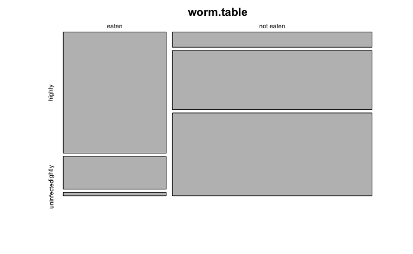

```r
mosaicplot(worm.table)
```

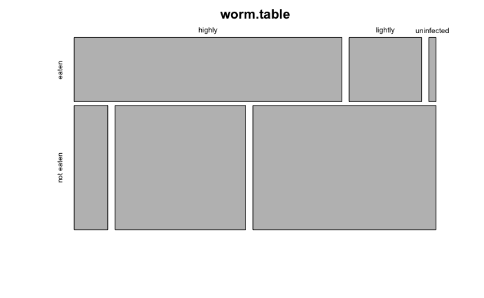

```r
#that looks not so great.  For plotting, let's switch the axes
mosaicplot(worm.table,
           dir = c("h","v")) #controls how to split the boxes (vertical, then horizontal by default).  See help file for more info.
```

We can pretty it up and make it more visually informative by adding colors.

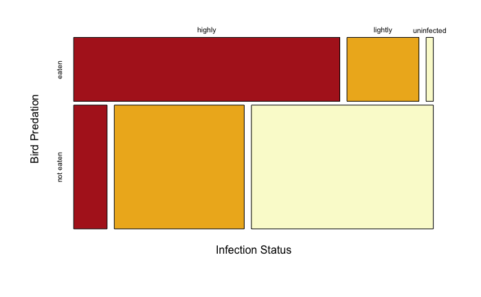

```r
mosaicplot(worm.table,
           dir = c("h","v"),
           color = c("firebrick", "goldenrod2", "lightgoldenrodyellow"),
           xlab = "Infection Status",
           ylab = "Bird Predation",
           main = NULL) #remove main title
```

```r
#for a list of valid color names:
# colors()
#R also understands hex codes:
# mosaicplot(worm.table,
#            dir = c("h", "v"),
#            color = c("#FF0202", "#FFA602", "#FFF502"),
#            xlab = "Infection Status",
#            ylab = "Fate",
#            main = NULL)
```

#### Exercise: Make a mosaic plot

Using the snail data you entered earlier, make a mosaic plot, and make it your own with colors and labels! Try to figure out what other graphical parameters you can change.

```r
(snails.result<-summary(snails.table))
```

```
Call: xtabs(formula = freq ~ color + predation, data = snails)
Number of cases in table: 1086
Number of factors: 2
Test for independence of all factors:
    Chisq = 8.583, df = 1, p-value = 0.003394
```

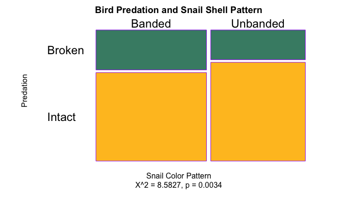

```r
mosaicplot(snails.table,
           color = c("aquamarine4", "goldenrod1"),
           border = "purple",
           xlab = "Snail Color Pattern",
           ylab = "Predation",
           main = "Bird Predation and Snail Shell Pattern",
           sub = paste0("X^2 = ",
                        round(snails.result$statistic, 4),
                        ", p = ",
                        round(snails.result$p.value, 4)),
           cex.axis = 1.5,
           las = 1)
```

### Mosaic plots in ggplot2

There is also a `ggmosaic` package which provides `geom_mosaic()` to ggplot. For our purposes, `mosaicplot()` is so simple that we’re not going to cover a ggplot way of making moasic plots. For more advanced mosaic plots, however, you may find `ggmosaic` helpful.